# Аналитика компьютерных игр для интернет-магазина "Стримчик". Изучение закономерностей, определяющих успешность игр.

**Описание проекта:**

Из открытых источников доступны исторические данные о продажах игр, оценки пользователей и экспертов, жанры и платформы (например, Xbox или PlayStation). Необходимо выявить определяющие успешность игры закономерности. Это позволит сделать ставку на потенциально популярный продукт и спланировать рекламные кампании.

**План проекта и основные задачи:**

1. Загрузка данных и краткое ознакомление с ними;
2. Предобработка данных (обработка пропусков, поиск дубликатов, приведение к нижнему регистру и т.д.)
3. Проведение исследовательского анализа данных:
- Исследование продаж и динамики продаж в разрезе платформ;
- Оценка влияния различных отзывов на продажи;
- Оценка продаж по жанрам и т.д.
4. Составление портрета пользователей разных регионов, оценка предпочтений.
5. Проверка гипотез
6. Подведение итогов, формулирование выводов.

```python
#подключим нужные модули и библиотеки
import pandas as pd
import datetime
import numpy as np
import matplotlib.pyplot as plt
from scipy import stats as st
import seaborn as sns
```

## Загрузка данных

```python
df = pd.read_csv('/datasets/games.csv')
pd.set_option('display.max_columns', 50)
```

```python
df.head(10)
```

|  | Name | Platform | Year_of_Release | Genre | NA_sales | EU_sales | JP_sales | Other_sales | Critic_Score | User_Score | Rating |
| --- | --- | --- | --- | --- | --- | --- | --- | --- | --- | --- | --- |
| 0 | Wii Sports | Wii | 2006.0 | Sports | 41.36 | 28.96 | 3.77 | 8.45 | 76.0 | 8 | E |
| 1 | Super Mario Bros. | NES | 1985.0 | Platform | 29.08 | 3.58 | 6.81 | 0.77 | NaN | NaN | NaN |
| 2 | Mario Kart Wii | Wii | 2008.0 | Racing | 15.68 | 12.76 | 3.79 | 3.29 | 82.0 | 8.3 | E |
| 3 | Wii Sports Resort | Wii | 2009.0 | Sports | 15.61 | 10.93 | 3.28 | 2.95 | 80.0 | 8 | E |
| 4 | Pokemon Red/Pokemon Blue | GB | 1996.0 | Role-Playing | 11.27 | 8.89 | 10.22 | 1.00 | NaN | NaN | NaN |
| 5 | Tetris | GB | 1989.0 | Puzzle | 23.20 | 2.26 | 4.22 | 0.58 | NaN | NaN | NaN |
| 6 | New Super Mario Bros. | DS | 2006.0 | Platform | 11.28 | 9.14 | 6.50 | 2.88 | 89.0 | 8.5 | E |
| 7 | Wii Play | Wii | 2006.0 | Misc | 13.96 | 9.18 | 2.93 | 2.84 | 58.0 | 6.6 | E |
| 8 | New Super Mario Bros. Wii | Wii | 2009.0 | Platform | 14.44 | 6.94 | 4.70 | 2.24 | 87.0 | 8.4 | E |
| 9 | Duck Hunt | NES | 1984.0 | Shooter | 26.93 | 0.63 | 0.28 | 0.47 | NaN | NaN | NaN |

```python
df.info()
```

```
<class 'pandas.core.frame.DataFrame'>
RangeIndex: 16715 entries, 0 to 16714
Data columns (total 11 columns):
 #   Column           Non-Null Count  Dtype
---  ------           --------------  -----
 0   Name             16713 non-null  object
 1   Platform         16715 non-null  object
 2   Year_of_Release  16446 non-null  float64
 3   Genre            16713 non-null  object
 4   NA_sales         16715 non-null  float64
 5   EU_sales         16715 non-null  float64
 6   JP_sales         16715 non-null  float64
 7   Other_sales      16715 non-null  float64
 8   Critic_Score     8137 non-null   float64
 9   User_Score       10014 non-null  object
 10  Rating           9949 non-null   object
dtypes: float64(6), object(5)
memory usage: 1.4+ MB
```

```python
df.isnull().sum()
```

```
Name                  2
Platform              0
Year_of_Release     269
Genre                 2
NA_sales              0
EU_sales              0
JP_sales              0
Other_sales           0
Critic_Score       8578
User_Score         6701
Rating             6766
dtype: int64
```

По первому взгляду на датасет, мождно сделать ряд выводов:

1. В датасете 16715 строк;
2. Пропущены значения в столбцах `'Name'`, `'Year_of_Release'`, `'Genre'`, `'Critic_Score'`, `'User_Score'`, `'Rating'`
3. Следует изменить тип данных в столбце `'Year_of_Release'` на DateTime;

Пропуски в столбцах 'name' и 'year_of_release', на мой взгляд скорее всего возникли в результате технических проблем. Возможно, пропуски с годом могут быть связаны с неточностями выхода игры или ее перезапусками.

Пропуски, содержащиеся в столбцах с оценкой возникли из-за человеческого фактора или отсутствием условий для оценки. Игры просто не получили свои оценки, как вариант, игры были непопулярны и не имели оценок, или игры не были представлены критикам. Также, возможно игры выходили в те годы, когда подсчет оценок еще не осуществлялся. Еще можно предположить, что на некоторых платформах просто не созданы условия для оценивания игр.

## Предобработка данных

```python
df.head(10)
```

|  | Name | Platform | Year_of_Release | Genre | NA_sales | EU_sales | JP_sales | Other_sales | Critic_Score | User_Score | Rating |
| --- | --- | --- | --- | --- | --- | --- | --- | --- | --- | --- | --- |
| 0 | Wii Sports | Wii | 2006.0 | Sports | 41.36 | 28.96 | 3.77 | 8.45 | 76.0 | 8 | E |
| 1 | Super Mario Bros. | NES | 1985.0 | Platform | 29.08 | 3.58 | 6.81 | 0.77 | NaN | NaN | NaN |
| 2 | Mario Kart Wii | Wii | 2008.0 | Racing | 15.68 | 12.76 | 3.79 | 3.29 | 82.0 | 8.3 | E |
| 3 | Wii Sports Resort | Wii | 2009.0 | Sports | 15.61 | 10.93 | 3.28 | 2.95 | 80.0 | 8 | E |
| 4 | Pokemon Red/Pokemon Blue | GB | 1996.0 | Role-Playing | 11.27 | 8.89 | 10.22 | 1.00 | NaN | NaN | NaN |
| 5 | Tetris | GB | 1989.0 | Puzzle | 23.20 | 2.26 | 4.22 | 0.58 | NaN | NaN | NaN |
| 6 | New Super Mario Bros. | DS | 2006.0 | Platform | 11.28 | 9.14 | 6.50 | 2.88 | 89.0 | 8.5 | E |
| 7 | Wii Play | Wii | 2006.0 | Misc | 13.96 | 9.18 | 2.93 | 2.84 | 58.0 | 6.6 | E |
| 8 | New Super Mario Bros. Wii | Wii | 2009.0 | Platform | 14.44 | 6.94 | 4.70 | 2.24 | 87.0 | 8.4 | E |
| 9 | Duck Hunt | NES | 1984.0 | Shooter | 26.93 | 0.63 | 0.28 | 0.47 | NaN | NaN | NaN |

### Приведем название столбцов к нижнему регистру.

```python
#сохраним копию датасета перед преобразованием
data = df
data.columns = data.columns.str.lower()
```

### Преобразуем данные в нужные типы.

Приведем столбец с датой к типу DateTime.

```python
data['year_of_release'].astype('Int64')
data['year_of_release'] = pd.to_datetime(data['year_of_release'],format='%Y')
```

Просмотрим столбец с оценкой критиков. Проверим - оценки являются целыми числами или числами с плавающей точкой? Если оценки выставляются целыми числами, приведем столбец к типу int.

```python
#узнаем, есть ли знаки после запятой?
data[(data['critic_score'].isnull() == False) & (data['critic_score'] % 1 != 0)]
data['critic_score'] = data['critic_score'].astype('Int64')
```

### Проработаем пропуски.

Рассмотрим столбец `'name'`, в нем содержится 2 пропуска, что составляет менее 0,5% от выборки. Как либо заполнить его мы не сможем, а значет его стоит удалить.

```python
#data[data['name'].isnull() == True]
data = data[~(data['name'].isnull() == True)]
```

Проработаем столбец `'year_of_release'`, в нем содержится 269 пропусков (примерно 1,5% от выборки). Достоверно заполнить год релиза мы не сможем (однако, для спортивных симуляторов годом релиза обычно является год, предшетсвующий году в названии игры). Но поскольку для дальнейших целей исследования год релиза будет важен, мы можем удалить строки, где он не указан.

```python
data = data[~(data['year_of_release'].isnull() == True)]
```

Рассмотрим столбец `'user_score'`. Оценки пользователей варьируются от 0 до 10. Столбец содержит 6605 пропусков, достоверно заполнить пропуски нет возможности, а значит оставим их.

Также, встречается аббревиатура 'tbd' - To Be Determined, то есть конкретная оценка еще не получена и будет определена в будущем. Чтобы в дальнейшем работать с этим столбцом, а также привести этот столбец к числовому типу, заменим значение 'tbd' на NaN.

```python
#data['user_score'].sort_values().unique()
#data.query('user_score == "tbd"')
data['user_score'] = data['user_score'].replace('tbd', np.NaN)
data['user_score'] = data['user_score'].astype('float64')
```

Просмотрим столбцы `'genre'` и `'platform'` на наличие неявных дубликатов.

```python
data['genre'].sort_values().unique()
```

```
array(['Action', 'Adventure', 'Fighting', 'Misc', 'Platform', 'Puzzle',
       'Racing', 'Role-Playing', 'Shooter', 'Simulation', 'Sports',
       'Strategy'], dtype=object)
```

```python
data['platform'].sort_values().unique()
```

```
array(['2600', '3DO', '3DS', 'DC', 'DS', 'GB', 'GBA', 'GC', 'GEN', 'GG',
       'N64', 'NES', 'NG', 'PC', 'PCFX', 'PS', 'PS2', 'PS3', 'PS4', 'PSP',
       'PSV', 'SAT', 'SCD', 'SNES', 'TG16', 'WS', 'Wii', 'WiiU', 'X360',
       'XB', 'XOne'], dtype=object)
```

Неявные дубликаты не обнаружены.

Посчитаем суммарные продажи во всех регионах и запишем их в отдельный столбец `'total_sales'`

```python
data['total_sales'] = data['na_sales'] + data['eu_sales'] + data['jp_sales'] + data['other_sales']
```

**Приведем стобцы 'name', 'platform', 'genre' к нижнему регистру и проверим датасет на наличие простых дубликатов.**

```python
# с помощью цикла приведем столбцы к нижнему регистру
cols = ['name', 'platform', 'genre']
for n in cols:
    data[n] = data[n].str.lower()
```

```python
# найдем дубликаты по 3 столбцам
data[data[['name', 'platform', 'year_of_release']].duplicated()]
```

|  | name | platform | year_of_release | genre | na_sales | eu_sales | jp_sales | other_sales | critic_score | user_score | rating | total_sales |
| --- | --- | --- | --- | --- | --- | --- | --- | --- | --- | --- | --- | --- |
| 16230 | madden nfl 13 | ps3 | 2012-01-01 | sports | 0.0 | 0.01 | 0.0 | 0.0 | 83 | 5.5 | E | 0.01 |

Удалим найденный дубликат.

```python
data = data.drop(labels = [16230], axis = 0)
data.reset_index(drop=True)
```

|  | name | platform | year_of_release | genre | na_sales | eu_sales | jp_sales | other_sales | critic_score | user_score | rating | total_sales |
| --- | --- | --- | --- | --- | --- | --- | --- | --- | --- | --- | --- | --- |
| 0 | wii sports | wii | 2006-01-01 | sports | 41.36 | 28.96 | 3.77 | 8.45 | 76 | 8.0 | E | 82.54 |
| 1 | super mario bros. | nes | 1985-01-01 | platform | 29.08 | 3.58 | 6.81 | 0.77 | <NA> | NaN | NaN | 40.24 |
| 2 | mario kart wii | wii | 2008-01-01 | racing | 15.68 | 12.76 | 3.79 | 3.29 | 82 | 8.3 | E | 35.52 |
| 3 | wii sports resort | wii | 2009-01-01 | sports | 15.61 | 10.93 | 3.28 | 2.95 | 80 | 8.0 | E | 32.77 |
| 4 | pokemon red/pokemon blue | gb | 1996-01-01 | role-playing | 11.27 | 8.89 | 10.22 | 1.00 | <NA> | NaN | NaN | 31.38 |
| ... | ... | ... | ... | ... | ... | ... | ... | ... | ... | ... | ... | ... |
| 16438 | samurai warriors: sanada maru | ps3 | 2016-01-01 | action | 0.00 | 0.00 | 0.01 | 0.00 | <NA> | NaN | NaN | 0.01 |
| 16439 | lma manager 2007 | x360 | 2006-01-01 | sports | 0.00 | 0.01 | 0.00 | 0.00 | <NA> | NaN | NaN | 0.01 |
| 16440 | haitaka no psychedelica | psv | 2016-01-01 | adventure | 0.00 | 0.00 | 0.01 | 0.00 | <NA> | NaN | NaN | 0.01 |
| 16441 | spirits & spells | gba | 2003-01-01 | platform | 0.01 | 0.00 | 0.00 | 0.00 | <NA> | NaN | NaN | 0.01 |
| 16442 | winning post 8 2016 | psv | 2016-01-01 | simulation | 0.00 | 0.00 | 0.01 | 0.00 | <NA> | NaN | NaN | 0.01 |

16443 rows × 12 columns

```python
# проверим, что дубликат удалился
data[data[['name', 'platform', 'year_of_release']].duplicated()]
```

|  | name | platform | year_of_release | genre | na_sales | eu_sales | jp_sales | other_sales | critic_score | user_score | rating | total_sales |
| --- | --- | --- | --- | --- | --- | --- | --- | --- | --- | --- | --- | --- |

**Посмотрим на датасет после предобработки данных.**

```python
def describe (df):
    return display(df.info(), df.head(10), df.isnull().sum())
```

```python
describe(data)
```

```
<class 'pandas.core.frame.DataFrame'>
Int64Index: 16443 entries, 0 to 16714
Data columns (total 12 columns):
 #   Column           Non-Null Count  Dtype
---  ------           --------------  -----
 0   name             16443 non-null  object
 1   platform         16443 non-null  object
 2   year_of_release  16443 non-null  datetime64[ns]
 3   genre            16443 non-null  object
 4   na_sales         16443 non-null  float64
 5   eu_sales         16443 non-null  float64
 6   jp_sales         16443 non-null  float64
 7   other_sales      16443 non-null  float64
 8   critic_score     7982 non-null   Int64
 9   user_score       7462 non-null   float64
 10  rating           9767 non-null   object
 11  total_sales      16443 non-null  float64
dtypes: Int64(1), datetime64[ns](1), float64(6), object(4)
memory usage: 1.6+ MB
```

```
None
```

|  | name | platform | year_of_release | genre | na_sales | eu_sales | jp_sales | other_sales | critic_score | user_score | rating | total_sales |
| --- | --- | --- | --- | --- | --- | --- | --- | --- | --- | --- | --- | --- |
| 0 | wii sports | wii | 2006-01-01 | sports | 41.36 | 28.96 | 3.77 | 8.45 | 76 | 8.0 | E | 82.54 |
| 1 | super mario bros. | nes | 1985-01-01 | platform | 29.08 | 3.58 | 6.81 | 0.77 | <NA> | NaN | NaN | 40.24 |
| 2 | mario kart wii | wii | 2008-01-01 | racing | 15.68 | 12.76 | 3.79 | 3.29 | 82 | 8.3 | E | 35.52 |
| 3 | wii sports resort | wii | 2009-01-01 | sports | 15.61 | 10.93 | 3.28 | 2.95 | 80 | 8.0 | E | 32.77 |
| 4 | pokemon red/pokemon blue | gb | 1996-01-01 | role-playing | 11.27 | 8.89 | 10.22 | 1.00 | <NA> | NaN | NaN | 31.38 |
| 5 | tetris | gb | 1989-01-01 | puzzle | 23.20 | 2.26 | 4.22 | 0.58 | <NA> | NaN | NaN | 30.26 |
| 6 | new super mario bros. | ds | 2006-01-01 | platform | 11.28 | 9.14 | 6.50 | 2.88 | 89 | 8.5 | E | 29.80 |
| 7 | wii play | wii | 2006-01-01 | misc | 13.96 | 9.18 | 2.93 | 2.84 | 58 | 6.6 | E | 28.91 |
| 8 | new super mario bros. wii | wii | 2009-01-01 | platform | 14.44 | 6.94 | 4.70 | 2.24 | 87 | 8.4 | E | 28.32 |
| 9 | duck hunt | nes | 1984-01-01 | shooter | 26.93 | 0.63 | 0.28 | 0.47 | <NA> | NaN | NaN | 28.31 |

```
name                  0
platform              0
year_of_release       0
genre                 0
na_sales              0
eu_sales              0
jp_sales              0
other_sales           0
critic_score       8461
user_score         8981
rating             6676
total_sales           0
dtype: int64
```

## Исследовательский анализ данных

### Посмотрим, сколько игр выпускалось в разные годы.

```python
year_count = data['year_of_release'].dt.year
year_count = (year_count.value_counts() \
              .rename_axis('year') \
              .reset_index(name='amount_of_games') \
              .sort_values(by='year')
             )
year_count.describe()
```

|  | year | amount_of_games |
| --- | --- | --- |
| count | 37.000000 | 37.000000 |
| mean | 1998.000000 | 444.405405 |
| std | 10.824355 | 451.591535 |
| min | 1980.000000 | 9.000000 |
| 25% | 1989.000000 | 36.000000 |
| 50% | 1998.000000 | 338.000000 |
| 75% | 2007.000000 | 762.000000 |
| max | 2016.000000 | 1427.000000 |

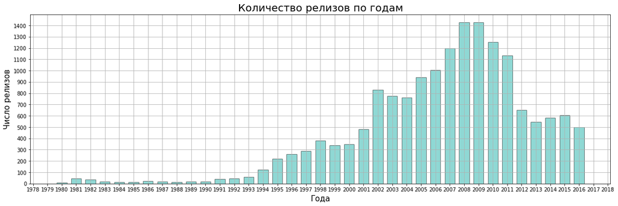

```python
from matplotlib.ticker import MultipleLocator

fig = plt.figure(figsize=(20,6))
ax = fig.add_subplot()

plt.title('Количество релизов по годам', fontdict = {'fontsize' : 20})
plt.xlabel('Года', fontdict = {'fontsize' : 15})
plt.ylabel('Число релизов', fontdict = {'fontsize' : 15})
plt.grid(True)

ax.bar(year_count['year'], year_count['amount_of_games'], width=0.7, color='#20B2AA', alpha=0.5, edgecolor = '#000000')
ax.xaxis.set_major_locator(MultipleLocator(base=1))
ax.yaxis.set_major_locator(MultipleLocator(base=100))

None
```

**Выводы:**

В целом, можно предположить, что помимо непосредственного количества релизов игр, график отражает развитие и выход на рынок новых игровых платформ и гейминга в целом.

### Посмотрим, как менялись продажи по платформам.

Для начала найдем платформы с наибольшими суммарными продажами за все время.

```python
#сгруппируем данные и выведем топ-6 платформ с наибольшими продажами
(data.groupby('platform')['total_sales'] \
 .sum() \
 .sort_values(ascending=False) \
 .head(6))
```

```
platform
ps2     1233.56
x360     961.24
ps3      931.33
wii      891.18
ds       802.78
ps       727.58
Name: total_sales, dtype: float64
```

Получились следующие платформы: PS2, X360, PS3, Wii, DS, PS

Сделаем сводную таблицу, сгруппированную по годам, с интересующими нас платформами и продажами.

```python
#создадим сводную таблицу
platform_year = data.pivot_table(index='year_of_release', \
                                 columns = 'platform',
                                 values='total_sales', aggfunc='sum')

#оставим только нужные нам платформы
top = platform_year.loc['1994-01-01':,['ps2', 'x360', 'ps3', 'wii', 'ds', 'ps']]
```

Построим график изменения продаж игр по платформам.

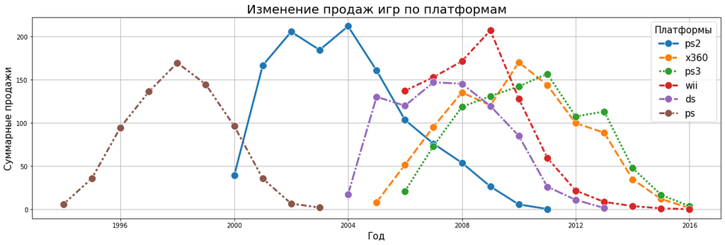

```python
fig = plt.figure(figsize=(20,6))
ax = fig.add_subplot()

plt.title('Изменение продаж игр по платформам', fontdict = {'fontsize' : 20})
plt.xlabel('Год', fontdict = {'fontsize' : 15})
plt.ylabel('Суммарные продажи', fontdict = {'fontsize' : 15})
plt.grid(True)

lines = sns.lineplot(data=top[['ps2', 'x360', 'ps3', 'wii', 'ds', 'ps']], linewidth=3, marker='o', markersize=12)
plt.legend(['ps2', 'x360', 'ps3', 'wii', 'ds', 'ps'], title='Платформы', fontsize=15, title_fontsize=15)

None
```

**Исходя из графика, можем сделать ряд наблюдений:**

1. Топ 3 платформы, с наибольшим суммарными продажами в год - PS2, X360, PS2;
2. На графике отчетливо видно три платформы, для которых перестали выходить игры - PS, PS2, DS. Для PS игры выходили 9 лет, для PS2 - 11 лет, для DS - 9 лет.
3. Поддержка PS3 и Xbox360 по официальным данным прекратилась в ~2016 (для разных стран по-разному), а значит эти платформы также можно оценить с точки зрения их появления и ухода. На PS3 игры выходили 10 лет, на X360 - 11 лет.
4. Для платформ, представленных на графике характерный срок существования находится в диапазоне от 9 до 11 лет.
5. Время с момента выхода первых игр до достижения максимальных суммарных продаж игр в год для разных платформ:
- PS - 4 года;
- PS2 - 4 года;
- PS3 - 5 лет;
- X360 - 5 лет;
- DS - 3 года.
6. Большинство наиболее популярных (с точки зрения продаж игр в год) платформ появлись с 2004 по 2006 год.

### Выделим данные за соответствующий актуальный период и проанализируем различные показатели

```python
goal = datetime.datetime(2013, 1, 1)
data_actual = data[data['year_of_release'] >= goal]
```

Поскольку нас интересуют данные, которые помогут построить прогноз на 2017 год, а также в связи с тем, что популярные платформы сменили свое поколение в 2013-2014 годах, для целей исследования, выделим актуальный период с 2013 года.

##### Рассмотрим какие платформы лидируют по продажам, растут и падают.

```python
actual_sales = data_actual.pivot_table(index='year_of_release', \
                                 columns = 'platform',
                                 values='total_sales', aggfunc='sum')
actual_sales
```

| platform year_of_release | 3ds | ds | pc | ps3 | ps4 | psp | psv | wii | wiiu | x360 | xone |
| --- | --- | --- | --- | --- | --- | --- | --- | --- | --- | --- | --- |
| 2013-01-01 | 56.57 | 1.54 | 12.38 | 113.25 | 25.99 | 3.14 | 10.59 | 8.59 | 21.65 | 88.58 | 18.96 |
| 2014-01-01 | 43.76 | NaN | 13.28 | 47.76 | 100.00 | 0.24 | 11.90 | 3.75 | 22.03 | 34.74 | 54.07 |
| 2015-01-01 | 27.78 | NaN | 8.52 | 16.82 | 118.90 | 0.12 | 6.25 | 1.14 | 16.35 | 11.96 | 60.14 |
| 2016-01-01 | 15.14 | NaN | 5.25 | 3.60 | 69.25 | NaN | 4.25 | 0.18 | 4.60 | 1.52 | 26.15 |

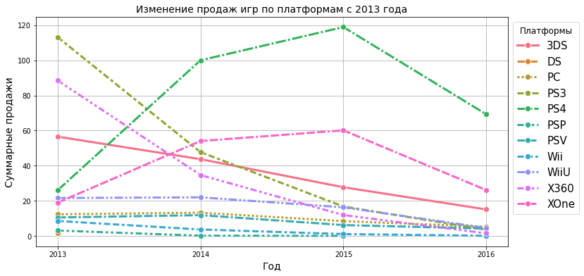

```python
import matplotlib.dates as mdates
fig = plt.figure(figsize=(12,6))
ax = fig.add_subplot()

plt.title('Изменение продаж игр по платформам c 2013 года', fontdict = {'fontsize' : 14})
plt.xlabel('Год', fontdict = {'fontsize' : 14})
plt.ylabel('Суммарные продажи', fontdict = {'fontsize' : 14})
plt.grid(True)

lines = sns.lineplot(data=actual_sales, linewidth=3, marker='o', markersize=8)
plt.legend(['3DS', 'DS', 'PC', 'PS3', 'PS4', 'PSP', 'PSV', 'Wii', 'WiiU', 'X360', 'XOne'], \
           title='Платформы', fontsize=15, title_fontsize=12, bbox_to_anchor=(1, 1))

ax.xaxis.set_major_locator(mdates.YearLocator())
year = mdates.DateFormatter('%Y')
ax.xaxis.set_major_formatter(year)

None
```

Для лучшей визуализации, сделаем два графика, с 5 платформами на одном и 6 платформами на другом.

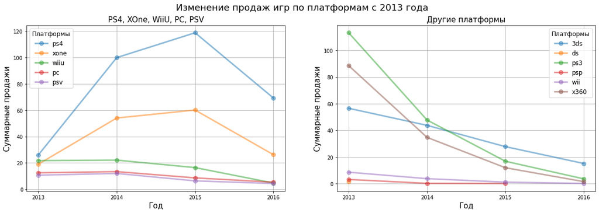

```python
fig, axs = plt.subplots(1, 2, figsize=(20,6))
fig.suptitle('Изменение продаж игр по платформам c 2013 года', size=18)

axs[0].plot(actual_sales[['ps4', 'xone', 'wiiu', 'pc', 'psv']], alpha=0.5, linewidth=3, marker='o', markersize=8)
axs[0].set_title('PS4, XOne, WiiU, PC, PSV', fontdict = {'fontsize' : 15})
axs[0].set_xlabel('Год', fontdict = {'fontsize' : 15})
axs[0].set_ylabel('Суммарные продажи', fontdict = {'fontsize' : 15})
axs[0].legend(['ps4', 'xone', 'wiiu', 'pc', 'psv'], \
           title='Платформы', fontsize=12, title_fontsize=12)
axs[0].xaxis.set_major_locator(mdates.YearLocator())
year = mdates.DateFormatter('%Y')
axs[0].xaxis.set_major_formatter(year)

axs[1].plot(actual_sales[['3ds', 'ds', 'ps3', 'psp', 'wii', 'x360']], alpha=0.5, linewidth=3, marker='o', markersize=8)
axs[1].set_title('Другие платформы', fontdict = {'fontsize' : 15})
axs[1].set_xlabel('Год', fontdict = {'fontsize' : 15})
axs[1].set_ylabel('Суммарные продажи', fontdict = {'fontsize' : 15})
axs[1].legend(['3ds', 'ds', 'ps3', 'psp', 'wii', 'x360'], \
           title='Платформы', fontsize=12, title_fontsize=12)
axs[1].xaxis.set_major_locator(mdates.YearLocator())
axs[1].xaxis.set_major_formatter(year)

axs[0].grid()
axs[1].grid()

None
```

Следует отметить, что поскольку данные за 2016 год неполные, падение количества проданных копий характерно для всех платформ.

##### Построим график «ящик с усами» по глобальным продажам игр в разбивке по платформам. Оценим результаты.

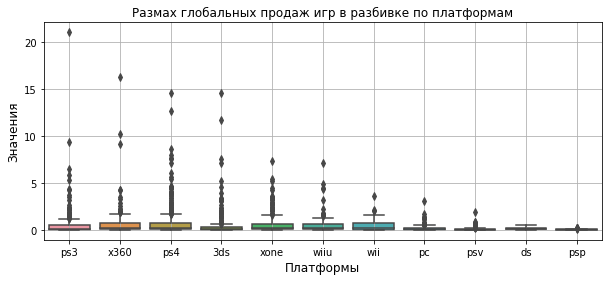

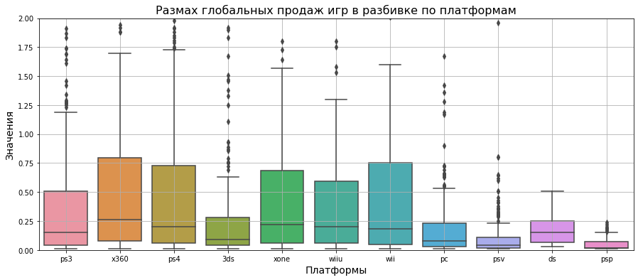

```python
fig = plt.figure(figsize=(10,4))
ax = fig.add_subplot()

boxplot = sns.boxplot(x='platform', y='total_sales', data=data_actual)
boxplot.axes.set_title('Размах глобальных продаж игр в разбивке по платформам', fontsize=12)
boxplot.set_xlabel('Платформы', fontsize=12)
boxplot.set_ylabel('Значения', fontsize=12);
plt.grid(True)

#для анализа графика, чтобы был виден 'ящик' и 'усы', установим лимит по y до 2 млн. копий
fig = plt.figure(figsize=(15,6))
ax = fig.add_subplot()

boxplot = sns.boxplot(x='platform', y='total_sales', data=data_actual)
boxplot.axes.set_title('Размах глобальных продаж игр в разбивке по платформам', fontsize=16)
boxplot.set_xlabel('Платформы', fontsize=14)
boxplot.set_ylabel('Значения', fontsize=14);
plt.grid(True)
plt.ylim(0, 2)

None
```

**Выводы:**

График "ящик с усами" в данном случае показывает нам размах числа проданных копий каждой игры в разрезе платформ. Соотвественно, чем больше выбросов у платформы, тем лучше продажи игр. Так же дело обстоит и с самим "ящиком", а конкретно - с "усами" и верхний квартилем, ведь чем он выше, тем на более высоком уровне находится количество проданных копий игр.

##### Посмотрим, как влияют на продажи внутри одной популярной платформы отзывы пользователей и критиков.

Построим диаграмму рассеяния и посчитаем корреляцию между отзывами и продажами для платформы PS4.

```python
#выберем данные для PS4
ps_4 = data_actual.query('platform == "ps4"')
#удалим пропуски, чтобы построить диаграму рассеяния
ps_4 = ps_4[['total_sales', 'critic_score', 'user_score']].dropna()
ps_4.corr().head(1)
```

|  | total_sales | critic_score | user_score |
| --- | --- | --- | --- |
| total_sales | 1.0 | 0.405895 | -0.033625 |

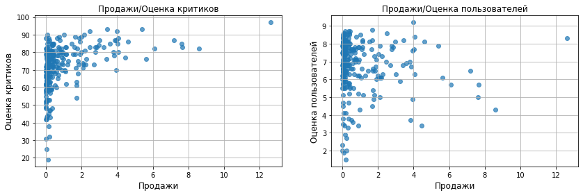

```python
fig, axs = plt.subplots(1, 2, figsize=(14,4))

axs[0].scatter(x=ps_4['total_sales'], y=ps_4['critic_score'], alpha=0.7)
axs[0].set_title('Продажи/Оценка критиков', fontdict = {'fontsize' : 12})
axs[0].set_xlabel('Продажи', fontdict = {'fontsize' : 12})
axs[0].set_ylabel('Оценка критиков', fontdict = {'fontsize' : 12})
axs[0].grid(True)

axs[1].scatter(x=ps_4['total_sales'], y=ps_4['user_score'], alpha=0.7)
axs[1].set_title('Продажи/Оценка пользователей', fontdict = {'fontsize' : 12})
axs[1].set_xlabel('Продажи', fontdict = {'fontsize' : 12})
axs[1].set_ylabel('Оценка пользователей', fontdict = {'fontsize' : 12})
axs[1].grid(True)

None
```

**Вывод по платформе PS4:**

1. Исходя из расчетов, существует корреляция между оценкой игры критиками и количеством продаж. Коэффициент корреляции составляет 0.405895, что говорит нам о том, что чем выше оценка критиков, тем выше продажи.
2. Корреляции между оценкой пользователей и продажами нет. Коэффициент близок к нулю и составляет всего ~-0.033625.

##### Посмотрим, как влияют на продажи отзывы пользователей и критиков для других платформ. Соотнесем выводы.

Сделаем функцию, которая будет выводить корелляцию.

```
Корреляция для xone
             total_sales  critic_score  user_score
total_sales          1.0      0.410422   -0.094003

Корреляция для ps3
             total_sales  critic_score  user_score
total_sales          1.0      0.333807    0.022691

Корреляция для wiiu
             total_sales  critic_score  user_score
total_sales          1.0      0.379504    0.408692

Корреляция для pc
             total_sales  critic_score  user_score
total_sales          1.0      0.194124   -0.109235

Корреляция для 3ds
             total_sales  critic_score  user_score
total_sales          1.0      0.339235     0.27299
```

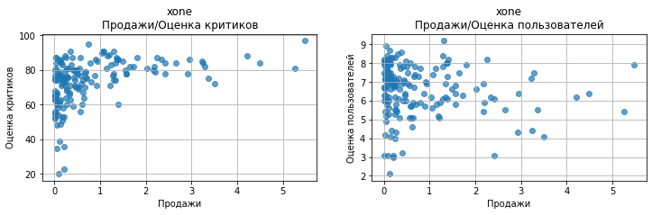

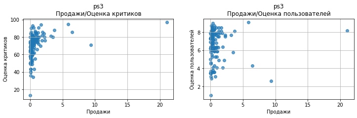

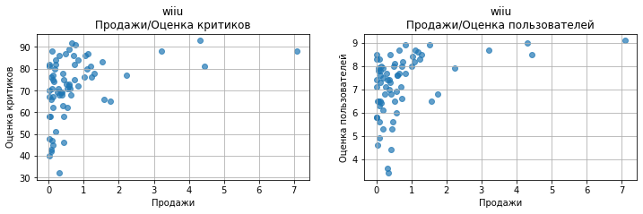

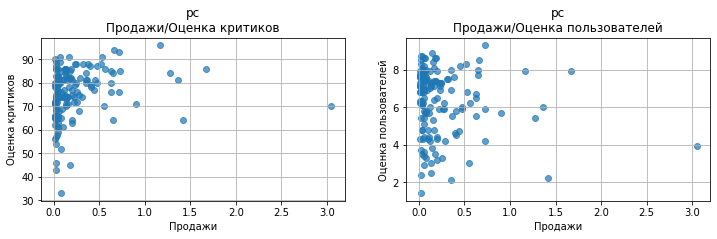

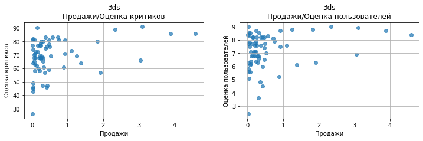

```python
#создадим список с необходимыми платформами
row = ['xone', 'ps3', 'wiiu', 'pc', '3ds']

#напишем функцию
def corr (row):
    for n in row:
        platform = (data_actual.loc[data_actual['platform'] == n][['total_sales', 'critic_score', 'user_score']] \
                               .dropna())
        print(f'Корреляция для {n}\n{platform.corr().head(1)}\n')

    for n in row:
        scatter_data = (data_actual.loc[data_actual['platform'] == n][['total_sales', 'critic_score', 'user_score']] \
                                   .dropna())
        fig, axs = plt.subplots(1, 2, figsize=(12,3))

        axs[0].scatter(x=scatter_data['total_sales'], y=scatter_data['critic_score'], alpha=0.7)
        axs[0].set_title(f'{n}\nПродажи/Оценка критиков', fontdict = {'fontsize' : 12})
        axs[0].set_xlabel('Продажи', fontdict = {'fontsize' : 10})
        axs[0].set_ylabel('Оценка критиков', fontdict = {'fontsize' : 10})
        axs[0].grid(True)

        axs[1].scatter(x=scatter_data['total_sales'], y=scatter_data['user_score'], alpha=0.7)
        axs[1].set_title(f'{n}\nПродажи/Оценка пользователей', fontdict = {'fontsize' : 12})
        axs[1].set_xlabel('Продажи', fontdict = {'fontsize' : 10})
        axs[1].set_ylabel('Оценка пользователей', fontdict = {'fontsize' : 10})
        axs[1].grid(True)
    return

corr(row)
```

**Выводы по остальным популярным платформам (XOne, PS3, WiiU, PC, 3DS):**

1. Для XOne заметна взаимосвязь между продажами и оценкой критиков (0.41), чем выше оценка критиков, тем выше продажи. Взаимосвязь между продажами и оценками пользователей не обнаружена (-0.094003).
2. Для PS3 корреляция между продажами и оценками критиков слабая и составляет 0.33, между продажами и оценкой пользователей корреляция не обнаружена (0.022).
3. Для WiiU корреляция заметна между продажами и оценками критиков (0.38) и между продажами и оценками пользователей (0.40).
4. Для PC показатели корреляции являются самыми низкими среди рассматриваемых платформ. Связи между продажами и оценкой критиков почти нет (0.19). Корреляции между продажами и оценками пользователей нет (-0.109).
5. Для 3DS коэффициенты корреляции положительные, видна слабая взаимосвязь. Между продажами и оценкой критиков = 0.34, продажами и оценкой пользователей = 0.27

**Рассмотрев самые популярные платформы и сопоставив с выбранной (PS4), можно выделить ряд моментов:**

1. Показатели корреляции продаж/оценок критиков, продаж/оценок пользователей у платформ PS4 и XOne схожа
2. У всех платформ, кроме WiiU и 3DS, взаимосвязь продажи/оценки пользователей не обнаружена.
3. WiiU единственная платформа, в которой коэффициенты корреляции почти одинаковы, а взаимосвязь заметна.

##### Посмотрим на общее распределение игр по жанрам. Изучим жанры с точки зрения прибыли

Посмотрим на распределение игр по жанрам, построим круговую диаграму.

```python
genre = pd.DataFrame(data_actual['genre'].value_counts())
genre.reset_index(inplace= True)
genre.columns = ['genre', 'games_amount']

genre
```

|  | genre | games_amount |
| --- | --- | --- |
| 0 | action | 766 |
| 1 | role-playing | 292 |
| 2 | adventure | 245 |
| 3 | sports | 214 |
| 4 | shooter | 187 |
| 5 | misc | 155 |
| 6 | racing | 85 |
| 7 | fighting | 80 |
| 8 | platform | 74 |
| 9 | simulation | 62 |
| 10 | strategy | 56 |
| 11 | puzzle | 17 |

```python
genre_sales = data_actual[['genre', 'total_sales']]
genre_sales = pd.DataFrame(genre_sales.groupby('genre')['total_sales'].agg(sum))
genre_sales.reset_index(inplace= True)
genre_sales = genre_sales.sort_values('total_sales')
```

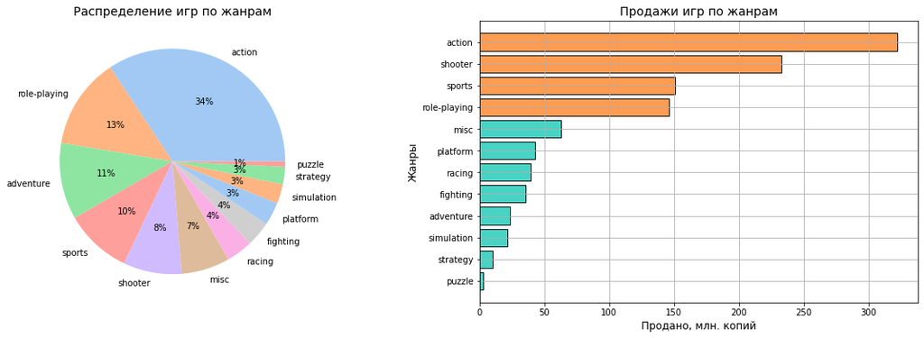

```python
fig, axs = plt.subplots(1, 2, figsize=(20,6))

colors = sns.color_palette('pastel')[0:8]
axs[0].pie(genre['games_amount'], labels = genre['genre'], colors = colors, autopct='%.0f%%')
axs[0].set_title('Распределение игр по жанрам', fontdict = {'fontsize' : 14})

color = ['#FF9140' if i > 100 else '#34CFBE' for i in genre_sales['total_sales']]
axs[1].barh(genre_sales['genre'], genre_sales['total_sales'], color=color, alpha=0.9, edgecolor = '#000000')
axs[1].set_title('Продажи игр по жанрам', fontdict = {'fontsize' : 14})
axs[1].set_xlabel('Продано, млн. копий', fontdict = {'fontsize' : 12})
axs[1].set_ylabel('Жанры', fontdict = {'fontsize' : 12})
plt.grid(True)



None
```

Проанализируем прибыльность жанров, используя диаграму размаха.

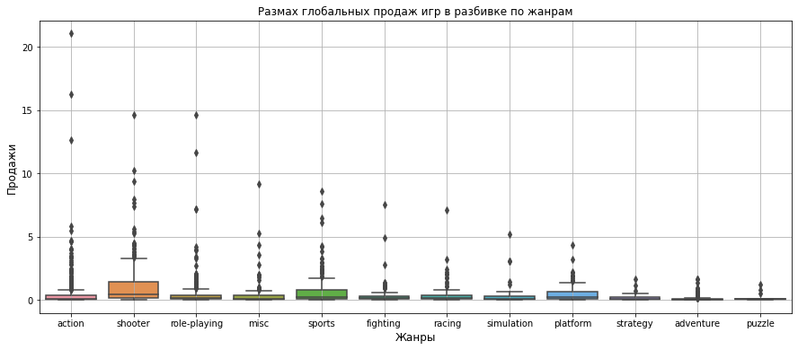

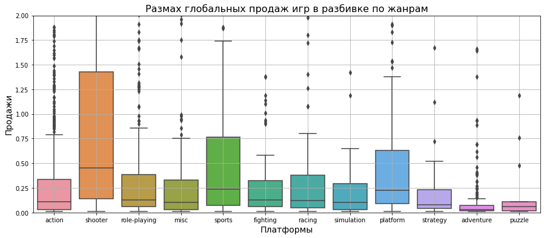

```python
fig = plt.figure(figsize=(15, 6))
ax = fig.add_subplot()

genre_plot = sns.boxplot(x='genre', y='total_sales', data=data_actual)
genre_plot.axes.set_title('Размах глобальных продаж игр в разбивке по жанрам', fontsize=12)
genre_plot.set_xlabel('Жанры', fontsize=12)
genre_plot.set_ylabel('Продажи', fontsize=12);
plt.grid(True)

#для анализа графика, чтобы был виден 'ящик' и 'усы', установим лимит по y до 2 млн. копий
fig = plt.figure(figsize=(15,6))
ax = fig.add_subplot()

genre_plot = sns.boxplot(x='genre', y='total_sales', data=data_actual)
genre_plot.axes.set_title('Размах глобальных продаж игр в разбивке по жанрам', fontsize=16)
genre_plot.set_xlabel('Платформы', fontsize=14)
genre_plot.set_ylabel('Продажи', fontsize=14);
plt.grid(True)
plt.ylim(0, 2)

None
```

**Выводы:**

1. Наиболее популярный жанр - Action.
2. Игры в жанре Shooter имеют самые высокие медианные продажи, далее следуют жанры Sports и Platform.
3. В среднем, медианные продажи для каждого жанра кроме Shooter не превышают 400 тыс. копий.
4. Жанры с играми-бестселлерами (проданными более 10 млн. копий) - Action, Shooter и Role-Playing.
5. Наиболее стабильные и продающиеся жанры помимо Action и Shooter - Platform, Sports, Role-Playing, Racing.

## Шаг. Составим портрет пользователя каждого региона.

```python
data_actual.head(5)
```

|  | name | platform | year_of_release | genre | na_sales | eu_sales | jp_sales | other_sales | critic_score | user_score | rating | total_sales |
| --- | --- | --- | --- | --- | --- | --- | --- | --- | --- | --- | --- | --- |
| 16 | grand theft auto v | ps3 | 2013-01-01 | action | 7.02 | 9.09 | 0.98 | 3.96 | 97 | 8.2 | M | 21.05 |
| 23 | grand theft auto v | x360 | 2013-01-01 | action | 9.66 | 5.14 | 0.06 | 1.41 | 97 | 8.1 | M | 16.27 |
| 31 | call of duty: black ops 3 | ps4 | 2015-01-01 | shooter | 6.03 | 5.86 | 0.36 | 2.38 | <NA> | NaN | NaN | 14.63 |
| 33 | pokemon x/pokemon y | 3ds | 2013-01-01 | role-playing | 5.28 | 4.19 | 4.35 | 0.78 | <NA> | NaN | NaN | 14.60 |
| 42 | grand theft auto v | ps4 | 2014-01-01 | action | 3.96 | 6.31 | 0.38 | 1.97 | 97 | 8.3 | M | 12.62 |

### Рассмотрим самые популярные платформы (топ-5) для каждого из регионов (NA, EU, JP).

```python
# Сначала выделим игроков по регионам.
na_users = data_actual[['platform', 'na_sales']]
eu_users = data_actual[['platform', 'eu_sales']]
jp_users = data_actual[['platform', 'jp_sales']]
```

```python
# Составим списки для функции
region = [na_users, eu_users, jp_users]
region_sales = ['na_sales', 'eu_sales', 'jp_sales']
```

```python
# Напишем функцию, которая будет группировать и сортировать данные по каждому из регионов
def sort (region):
    column = [col for col in region.columns if 'sales' in col]
    region = pd.DataFrame(region.groupby('platform')[column].agg(sum))
    region.reset_index(inplace= True)
    region = region.sort_values(column, ascending=False)
    region.reset_index(drop = True, inplace= True)
    return region

na_users = sort(na_users)
eu_users = sort(eu_users)
jp_users = sort(jp_users)
```

```python
eu_users
```

|  | platform | eu_sales |
| --- | --- | --- |
| 0 | ps4 | 141.09 |
| 1 | ps3 | 67.81 |
| 2 | xone | 51.59 |
| 3 | x360 | 42.52 |
| 4 | 3ds | 30.96 |
| 5 | pc | 25.36 |
| 6 | wiiu | 19.85 |
| 7 | psv | 6.10 |
| 8 | wii | 5.93 |
| 9 | ds | 0.85 |
| 10 | psp | 0.17 |

```python
# Оставим только 5 наиболее популярных платформ, а остальные переведем в категорию "Другие"
na_users['platform'] = na_users['platform'].where(na_users['na_sales'].isin(na_users['na_sales'].nlargest(5)), 'Другие')
na_users = pd.DataFrame(na_users.groupby('platform')['na_sales'].agg(sum))
na_users.reset_index(inplace= True)

eu_users['platform'] = eu_users['platform'].where(eu_users['eu_sales'].isin(eu_users['eu_sales'].nlargest(5)), 'Другие')
eu_users = pd.DataFrame(eu_users.groupby('platform')['eu_sales'].agg(sum))
eu_users.reset_index(inplace= True)

jp_users['platform'] = jp_users['platform'].where(jp_users['jp_sales'].isin(jp_users['jp_sales'].nlargest(5)), 'Другие')
jp_users = pd.DataFrame(jp_users.groupby('platform')['jp_sales'].agg(sum))
jp_users.reset_index(inplace= True)
```

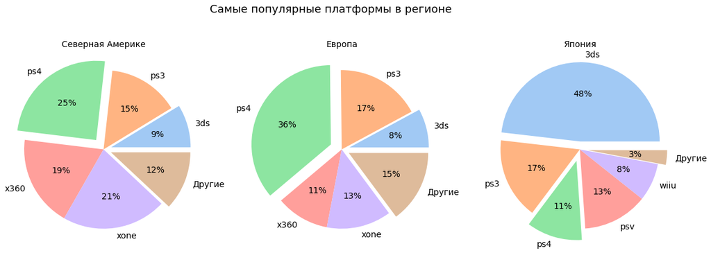

```python
fig, axs = plt.subplots(1, 3, figsize=(20,7))
fig.suptitle('Cамые популярные платформы в регионе', size=18)
explode = (0.1, 0, 0.15, 0, 0, 0.1)
colors = sns.color_palette('pastel')[0:6]

axs[0].pie(na_users['na_sales'], labels = na_users['platform'], colors = colors, autopct='%.0f%%', \
           explode = explode, textprops={'fontsize': 14})
axs[0].set_title('Северная Америке', fontdict = {'fontsize' : 14})


axs[1].pie(eu_users['eu_sales'], labels = eu_users['platform'], colors = colors, autopct='%.0f%%', \
           explode = explode, textprops={'fontsize': 14})
axs[1].set_title('Европа', fontdict = {'fontsize' : 14})


axs[2].pie(jp_users['jp_sales'], labels = jp_users['platform'], colors = colors, autopct='%.0f%%', \
           explode = explode, textprops={'fontsize': 14})
axs[2].set_title('Япония', fontdict = {'fontsize' : 14})

None
```

**Выводы:**

1. В Северной Америке и Европе по популярности лидирует PS4, в Японии - платформа 3DS;
2. Распределение платформ по популярности в Северной Америке и Европе схожи, однако существует разница в долях;
3. В топ-5 популярных платформ в Японии находятся 2 платформы (PSV, WiiU), которые не характерны для других регионов.
4. Доля платформ "Другие" в Японии составляет 3%, в то время, как для Северной Америки этот показатель составляет 12% и 15% соотвественно.

### Проанализируем самые популярные жанры (топ-5) для каждого из регионов.

```python
na_genres = data_actual[['genre', 'na_sales']]
eu_genres = data_actual[['genre', 'eu_sales']]
jp_genres = data_actual[['genre', 'jp_sales']]
```

```python
genre = [na_genres, eu_genres, jp_genres]
region_sales = ['na_sales', 'eu_sales', 'jp_sales']
```

```python
def srt (genre):
    column = [col for col in genre.columns if 'sales' in col]
    genre = pd.DataFrame(genre.groupby('genre')[column].agg(sum))
    genre.reset_index(inplace= True)
    genre = genre.sort_values(column, ascending=False)
    genre.reset_index(drop = True, inplace= True)
    return genre

na_genres = srt(na_genres)
eu_genres = srt(eu_genres)
jp_genres = srt(jp_genres)
```

```python
na_genres['genre'] = (na_genres['genre']
                         .where(na_genres['na_sales'].isin(na_genres['na_sales'].nlargest(5)), 'Другие'))
na_genres = pd.DataFrame(na_genres.groupby('genre')['na_sales'].agg(sum))
na_genres.reset_index(inplace= True)

eu_genres['genre'] = eu_genres['genre'].where(eu_genres['eu_sales'].isin(eu_genres['eu_sales'].nlargest(5)), 'Другие')
eu_genres = pd.DataFrame(eu_genres.groupby('genre')['eu_sales'].agg(sum))
eu_genres.reset_index(inplace= True)

jp_genres['genre'] = jp_genres['genre'].where(jp_genres['jp_sales'].isin(jp_genres['jp_sales'].nlargest(5)), 'Другие')
jp_genres = pd.DataFrame(jp_genres.groupby('genre')['jp_sales'].agg(sum))
jp_genres.reset_index(inplace= True)
```

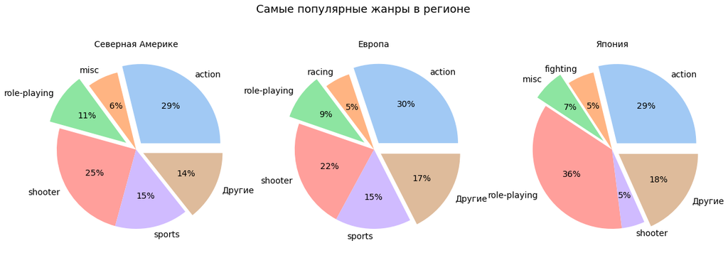

```python
fig, axs = plt.subplots(1, 3, figsize=(20,7))
fig.suptitle('Cамые популярные жанры в регионе', size=18)
explode = (0.1, 0, 0.15, 0, 0, 0.1)
colors = sns.color_palette('pastel')[0:6]

axs[0].pie(na_genres['na_sales'], labels = na_genres['genre'], colors = colors, autopct='%.0f%%', \
           explode = explode, textprops={'fontsize': 14})
axs[0].set_title('Северная Америке', fontdict = {'fontsize' : 14})

axs[1].pie(eu_genres['eu_sales'], labels = eu_genres['genre'], colors = colors, autopct='%.0f%%', \
           explode = explode, textprops={'fontsize': 14})
axs[1].set_title('Европа', fontdict = {'fontsize' : 14})

axs[2].pie(jp_genres['jp_sales'], labels = jp_genres['genre'], colors = colors, autopct='%.0f%%', \
           explode = explode, textprops={'fontsize': 14})
axs[2].set_title('Япония', fontdict = {'fontsize' : 14})

None
```

**Выводы:**

1. Наиболее популрный жанр в Северной Америке и Европе - Action, в Японии - Role-Playing;
2. Топ-5 популярных жанров в Северной Америке и в Европе схож, за исключением жанров Racing и Misc, жанр Racing присущ пользователям из Европы, Misc - Северной Америке.
3. Как и в случае с популярностью платформ, Япония отличается распределением. Так, более 60% проданных релизов находятся в жанре Action или Role-Playing.

### Рассмотрим, влияет ли рейтинг ESRB на продажи в отдельном регионе?

Построим график, отображающий продажи в Европе в зависимости от рейтинга игры. Сделаем сводную таблицу.

```python
esrb = data_actual.pivot_table(index='rating', values='eu_sales', aggfunc=sum).reset_index()
```

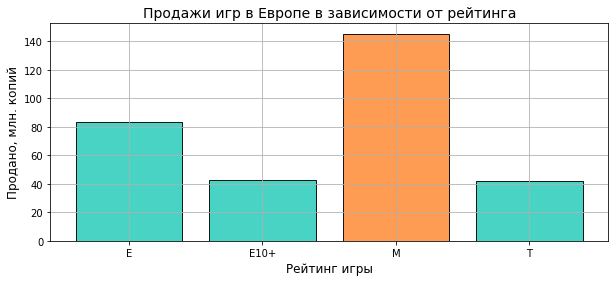

```python
fig = plt.figure(figsize=(10,4))
ax = fig.add_subplot()

color = ['#FF9140' if i > 100 else '#34CFBE' for i in esrb['eu_sales']]
plt.bar(esrb['rating'], esrb['eu_sales'], color=color, alpha=0.9, edgecolor = '#000000')
plt.title('Продажи игр в Европе в зависимости от рейтинга', fontdict = {'fontsize' : 14})
plt.ylabel('Продано, млн. копий', fontdict = {'fontsize' : 12})
plt.xlabel('Рейтинг игры', fontdict = {'fontsize' : 12})
plt.grid(True)

None
```

**Вывод:**

С лидирующим отрывом, большинство проданных игр в Европе за рассматриваемый период имеют возрастной рейтинг "M" - для лиц старше 17 лет. Далее следуют игры с рейтингом "E" - для всех возрастных категорий. Меньше всего игр продано в рейтинге "E10+" - для всех от 10 лет и старше и рейтинге "Т" - для подростков.

**Проработаем столбец с рейтингом, заменим пропуски на 'Не определен', оценим как изменится распределение**

```python
esrb_v2 = data_actual[['eu_sales', 'rating']].fillna('Не определен')
esrb_v2['rating'].value_counts()
```

```
Не определен    977
M               369
T               333
E               302
E10+            252
Name: rating, dtype: int64
```

```python
esrb_v2 = esrb_v2.pivot_table(index='rating', values='eu_sales', aggfunc=sum).reset_index()
```

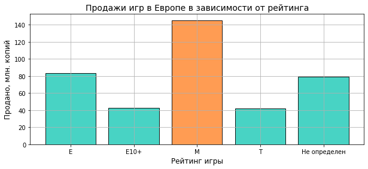

```python
fig = plt.figure(figsize=(10,4))
ax = fig.add_subplot()

color = ['#FF9140' if i > 100 else '#34CFBE' for i in esrb_v2['eu_sales']]
plt.bar(esrb_v2['rating'], esrb_v2['eu_sales'], color=color, alpha=0.9, edgecolor = '#000000')
plt.title('Продажи игр в Европе в зависимости от рейтинга', fontdict = {'fontsize' : 14})
plt.ylabel('Продано, млн. копий', fontdict = {'fontsize' : 12})
plt.xlabel('Рейтинг игры', fontdict = {'fontsize' : 12})
plt.grid(True)

None
```

**Вывод:** Добавив к сравнению количество игр для которых рейтинг не установлен, произошли некоторые изменения на графике. Игры с рейтингом "M" (для лиц старше 17 лет) по прежнему лидируют по количеству проданных копий. Однако суммарные продажи игр для которых рейтинг не установлен примерно равны суммарным продажам игр с рейтингом "E10+" и "Т" вместе взятых, а также примерно равны продажам игр с рейтингом "E".

## Шаг. Проверим гипотезы.

### Проверим гипотезу о том, что средние пользовательские рейтинги платформ Xbox One и PC одинаковые;

Нулевая гипотеза: средние пользовательские рейтинги платформ Xbox One и PC равны;

Альтернативная: средние пользовательские рейтинги платформ Xbox One и PC не равны.

```python
XOne_user_score = data_actual.query('platform == "xone"')['user_score'].dropna()
PC_user_score = data_actual.query('platform == "pc"')['user_score'].dropna()

alpha = 0.01

results = st.ttest_ind(XOne_user_score, PC_user_score)

print(f'p-value: {results.pvalue}')

if results.pvalue < alpha:
    print('Отвергаем нулевую гипотезу')
else:
    print('Нет оснований отвергнуть нулевую гипотезу')
```

```
p-value: 0.14012658403611647
Нет оснований отвергнуть нулевую гипотезу
```

Исходя из результатов теста, у нас нет оснований отвергнуть нулевую гипотезу, а значит что средние пользовательские рейтинги платформ Xbox One и PC могут быть одинаковы.

### Проверим гипотезу о том, что cредние пользовательские рейтинги жанров Action и Sports разные.

Нулевая гипотеза: средние пользовательские рейтинги жанров Action и Sports равны;

Альтернативная: средние пользовательские рейтинги жанров Action и Sports равны не равны.

```python
action = data_actual.query('genre == "action"')['user_score'].dropna()
sports = data_actual.query('genre == "sports"')['user_score'].dropna()


alpha = 0.01

results = st.ttest_ind(action, sports)

print(f'p-value: {results.pvalue}')

if results.pvalue < alpha:
    print('Отвергаем нулевую гипотезу')
else:
    print('Нет оснований отвергнуть нулевую гипотезу')
```

```
p-value: 1.0517832389140023e-27
Отвергаем нулевую гипотезу
```

Поскольку мы можем отвергнуть нулевую гипотезу, вероятно, что cредние пользовательские рейтинги жанров Action и Sports скорее разные.

## Общий вывод

**Проект заключался в выявлении определяющих успешность игры закономерностях, с целью выбора потенциально популярных продуктов и рационального планирования рекламных кампаний для интернет-магазине «Стримчик».**

Были получены данные о продажах игр, оценках пользователей и экспертов, жанрах и платформах за длительный срок.

**На этапе исследовательского анализ были рассмотрены различные показатели продаж игр, количественные характеристики игр, показатели, характеризующие платформы и жанры. Также, в связи со спецификой рассматриваемой области, был определен период, начиная с которого данные можно считать актуальными (с 2013 года).**

**Некоторые выводы (по всему периоду):**

1. Топ 3 платформы, с наибольшим суммарными продажами в год (за все время) - PS2, X360, PS2;
2. Большинство наиболее популярных (с точки зрения продаж игр в год) платформ появлись с 2004 по 2006 год.
3. Характерный срок существования платформ находится в диапазоне от 9 до 11 лет.

**Были составлены портреты пользователей для каждого из регионов. Получены следующие выводы:**

1. В Северной Америке и Европе по популярности лидирует PS4, в Японии - платформа 3DS;
2. Распределение платформ по популярности в Северной Америке и Европе схожи, однако существует разница в долях;
3. В топ-5 популярных платформ в Японии находятся 2 платформы (PSV, WiiU), которые не характерны для других регионов.
4. Доля платформ "Другие" в Японии составляет 3%, в то время, как для Северной Америки этот показатель составляет 12% и 15% соотвественно.
5. Наиболее популрный жанр в Северной Америке и Европе - Action, в Японии - Role-Playing;
6. Топ-5 популярных жанров в Северной Америке и в Европе схож, за исключением жанров Racing и Misc, жанр Racing присущ пользователям из Европы, Misc - Северной Америке.
7. Как и в случае с популярностью платформ, Япония отличается распределением. Так, более 60% проданных релизов находятся в жанре Action или Role-Playing.
8. Большинство проданных игр в Европе за рассматриваемый период имеют возрастной рейтинг "M" - для лиц старше 17 лет. Далее следуют игры с рейтингом "E" - для всех возрастных категорий. Меньше всего игр продано в рейтинге "E10+" - для всех от 10 лет и старше и рейтинге "Т" - для подростков. Добавив к сравнению количество игр для которых рейтинг не установлен, произошли некоторые изменения на графике. Игры с рейтингом "M" (для лиц старше 17 лет) по прежнему лидируют по количеству проданных копий. Однако суммарные продажи игр для которых рейтинг не установлен примерно равны суммарным продажам игр с рейтингом "E10+" и "Т" вместе взятых, а также примерно равны продажам игр с рейтингом "E".

**Были проверены некоторые гипотезы, касающиеся равенства средних пользовательских рейтингов для платформ и для жанров, сформулированы выводы:**

1. Средние пользовательские рейтинги на платформах Xbox One и PC могут быть одинаковы.
2. Вероятно, что cредние пользовательские рейтинги жанров Action и Sports скорее разные.

В заключение, стоит отметить, что игровая индустрия очень специфична и динамична, а актуальность данных за предыдущие года с выходом новых игр/платформ сильно снижается, это следует учитывать при построении маркетинговых компаний и ведения бизнеса в целом. Также, в индустрии отчетливы видны платформы-лидеры с многомиллиоными продажами и нишевые платформы, характерные для определенной группы геймеров из определенных регионов, на это так же стоит обратить внимание. Вдобавок, следует помнить о жанровых предпочтениях пользователей в различных странах, особенно это актуально для бизнеса, который охватывает несколько регионов.